# ASS3

Bryce Butler

2024-11-04

# I Completed 16/16

# Get WD

```r
getwd()
```

```
## [1] "/Users/bryce./Downloads/PROJECTS/FALL224753butl0072"
```

# Problem 1 (5.54)

1. **Probability of Observing an Interarrival Time of at Least 2 Minutes**

   Given that the interarrival time $X$ follows an exponential distribution with mean $\beta = 95$, calculate the probability that the interarrival time is at least 2 minutes (120 seconds):

   $$P(X \geq 120) = e^{-\frac{120}{\beta}}$$
2. **Goodness-of-Fit Test for Exponential Distribution**

   To determine if the data follows an exponential distribution with $\beta = 95$, perform a Kolmogorov-Smirnov test using the empirical data.

```r
# Load the data
phishing_data <- read.csv("phishing.csv")

# Part (a): Probability of observing an interarrival time of at least 2 minutes
beta <- 95  # mean interarrival time
time_in_seconds <- 2 * 60  # 2 minutes in seconds

# Calculate the probability for an exponential distribution
prob <- pexp(time_in_seconds, rate = 1 / beta, lower.tail = FALSE)
cat("The probability of observing an interarrival time of at least 2 minutes:", round(prob, 4), "\n")
```

```
## The probability of observing an interarrival time of at least 2 minutes: 0.2828
```

```r
# Part (b): Check if the data follows an exponential distribution with beta = 95
# Load the data and perform a goodness-of-fit test
interarrival_times <- phishing_data$INTTIME

# Perform Kolmogorov-Smirnov test
ks_test <- ks.test(interarrival_times, "pexp", rate = 1 / beta)
print("Kolmogorov-Smirnov test result:")
```

```
## [1] "Kolmogorov-Smirnov test result:"
```

```r
print(ks_test)
```

```
##
##  Asymptotic one-sample Kolmogorov-Smirnov test
##
## data:  interarrival_times
## D = 0.032611, p-value = 0.939
## alternative hypothesis: two-sided
```

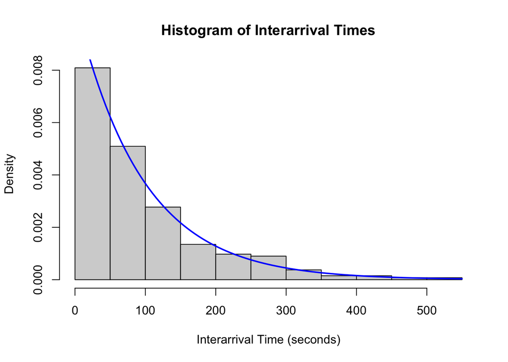

```r
# Plot the histogram and theoretical exponential density
hist(interarrival_times, prob = TRUE, main = "Histogram of Interarrival Times",
     xlab = "Interarrival Time (seconds)", ylab = "Density")
curve(dexp(x, rate = 1 / beta), col = "blue", lwd = 2, add = TRUE)
```

# Problem 2 (5.56)

1. **Mean and Variance of the Gamma Distribution**

   $$\text{Mean} = \alpha \cdot \beta$$
   $$\text{Variance} = \alpha \cdot \beta^2$$
2. **Probability of Observing a Flood Level of 0.60 or Higher**

   $$P(X \geq 0.60) = 1 - F(0.60)$$

```r
# Parameters for the gamma distribution
alpha <- 3
beta <- 0.07

# Part (a): Calculate the mean and variance
mean_flood <- alpha * beta
variance_flood <- alpha * beta^2

cat("Mean of the maximum flood level:", mean_flood, "\n")
```

```
## Mean of the maximum flood level: 0.21
```

```r
cat("Variance of the maximum flood level:", variance_flood, "\n")
```

```
## Variance of the maximum flood level: 0.0147
```

```r
# Part (b): Probability of observing a flood level of 0.60 or higher
flood_level <- 0.60
probability <- pgamma(flood_level, shape = alpha, scale = beta, lower.tail = FALSE)

cat("Probability of observing a flood level of 0.60 or higher:", round(probability, 4), "\n")
```

```
## Probability of observing a flood level of 0.60 or higher: 0.0088
```

```r
# Interpretation
if (probability < 0.05) {
  cat("A flood level of 0.60 million cubic feet per second is unusual for this gamma distribution.\n")
} else {
  cat("A flood level of 0.60 million cubic feet per second is not unusual for this gamma distribution.\n")
}
```

```
## A flood level of 0.60 million cubic feet per second is unusual for this gamma distribution.
```

# Problem 3 (5.60)

1. **Mean of Reaction Time for Both Formulas**

   $$\text{Mean} = \alpha \cdot \beta$$
2. **Variance of Reaction Time for Both Formulas**

   $$\text{Variance} = \alpha \cdot \beta^2$$
3. **Probability of Reaction in Less Than 1 Minute**

   For formula A:
   $$P(Y < 1) = F(1)$$

   For formula B:
   $$P(Y < 1) = F(1)$$

```r
# Parameters for gamma distributions
alpha_A <- 2
beta_A <- 2
alpha_B <- 1
beta_B <- 4

# Part (a): Mean for both distributions
mean_A <- alpha_A * beta_A
mean_B <- alpha_B * beta_B

cat("Mean for formula A:", mean_A, "\n")
```

```
## Mean for formula A: 4
```

```r
cat("Mean for formula B:", mean_B, "\n")
```

```
## Mean for formula B: 4
```

```r
# Part (b): Variance for both distributions
variance_A <- alpha_A * beta_A^2
variance_B <- alpha_B * beta_B^2

cat("Variance for formula A:", variance_A, "\n")
```

```
## Variance for formula A: 8
```

```r
cat("Variance for formula B:", variance_B, "\n")
```

```
## Variance for formula B: 16
```

```r
# Part (c): Probability of reaction in less than 1 minute
time_threshold <- 1  # 1 minute

# Probability for formula A
prob_A <- pgamma(time_threshold, shape = alpha_A, scale = beta_A, lower.tail = TRUE)
cat("Probability of reaction in less than 1 minute for formula A:", round(prob_A, 4), "\n")
```

```
## Probability of reaction in less than 1 minute for formula A: 0.0902
```

```r
# Probability for formula B
prob_B <- pgamma(time_threshold, shape = alpha_B, scale = beta_B, lower.tail = TRUE)
cat("Probability of reaction in less than 1 minute for formula B:", round(prob_B, 4), "\n")
```

```
## Probability of reaction in less than 1 minute for formula B: 0.2212
```

```r
# Determine which formula has the higher probability
if (prob_A > prob_B) {
  cat("Formula A has a higher probability of generating a reaction in less than 1 minute.\n")
} else if (prob_B > prob_A) {
  cat("Formula B has a higher probability of generating a reaction in less than 1 minute.\n")
} else {
  cat("Both formulas have the same probability of generating a reaction in less than 1 minute.\n")
}
```

```
## Formula B has a higher probability of generating a reaction in less than 1 minute.
```

# Problem 4 (5.74)

1. **Proportion of Machines Needing Repair Within 2 Years**

   $$P(Y \leq 2) = F(2)$$
2. **Mean and Variance of the Weibull Distribution**

   $$\text{Mean} = \beta \cdot \Gamma\left(1 + \frac{1}{\alpha}\right)$$
   $$\text{Variance} = \beta^2 \left[\Gamma\left(1 + \frac{2}{\alpha}\right)
   - \left(\Gamma\left(1 + \frac{1}{\alpha}\right)\right)^2\right]$$
3. **Probability Interval**

   $$P(\mu - 2\sigma \leq Y \leq \mu + 2\sigma)$$
4. **Probability of Exceeding 6 Years**

   $$P(Y > 6) = 1 - F(6)$$

```r
# Parameters for Weibull distribution
alpha <- 2  # shape parameter
beta <- 4   # scale parameter

# Part (a): Proportion needing repair within 2 years
time_threshold <- 2
prob_under_warranty <- pweibull(time_threshold, shape = alpha, scale = beta, lower.tail = TRUE)
cat("Proportion of machines needing repair within 2 years:", round(prob_under_warranty, 4), "\n")
```

```
## Proportion of machines needing repair within 2 years: 0.2212
```

```r
# Part (b): Mean and standard deviation
mean_repair_time <- beta * gamma(1 + 1 / alpha)
variance_repair_time <- (beta^2) * (gamma(1 + 2 / alpha) - (gamma(1 + 1 / alpha))^2)
sd_repair_time <- sqrt(variance_repair_time)

cat("Mean repair time:", round(mean_repair_time, 4), "\n")
```

```
## Mean repair time: 3.5449
```

```r
cat("Standard deviation of repair time:", round(sd_repair_time, 4), "\n")
```

```
## Standard deviation of repair time: 1.853
```

```r
# Part (c): Probability interval P(mu - 2 * sigma <= Y <= mu + 2 * sigma)
lower_bound <- mean_repair_time - 2 * sd_repair_time
upper_bound <- mean_repair_time + 2 * sd_repair_time
prob_interval <- pweibull(upper_bound, shape = alpha, scale = beta) - pweibull(lower_bound, shape = alpha, scale = beta)

cat("Probability that Y is within two standard deviations of the mean:", round(prob_interval, 4), "\n")
```

```
## Probability that Y is within two standard deviations of the mean: 0.9626
```

```r
# Part (d): Probability that Y exceeds 6 years
time_threshold_6 <- 6
prob_exceeds_6 <- pweibull(time_threshold_6, shape = alpha, scale = beta, lower.tail = FALSE)
cat("Probability that Y exceeds 6 years:", round(prob_exceeds_6, 4), "\n")
```

```
## Probability that Y exceeds 6 years: 0.1054
```

# Problem 5 (5.84)

1. **Mean and Variance of $Y$**

   For a Beta distribution with parameters $\alpha$ and $\beta$, the mean and variance are given by:

   $$\text{Mean} = \frac{\alpha}{\alpha + \beta}$$
   $$\text{Variance} = \frac{\alpha \cdot \beta}{(\alpha + \beta)^2 \cdot
   (\alpha + \beta + 1)}$$
2. **Probability that at Least 40% of the Budget is Used**

   Find the probability that $Y \geq 0.4$:

   $$P(Y \geq 0.4) = 1 - F(0.4)$$

   where $F(y)$ is the cumulative distribution function of the Beta distribution.
3. **Probability that at Most 10% of the Budget is Used**

   Find the probability that $Y \leq 0.1$:

   $$P(Y \leq 0.1) = F(0.1)$$

```r
# Parameters for the beta distribution
alpha <- 2
beta <- 9

# Part (a): Mean and Variance of Y
mean_Y <- alpha / (alpha + beta)
variance_Y <- (alpha * beta) / ((alpha + beta)^2 * (alpha + beta + 1))

cat("Mean of Y:", round(mean_Y, 4), "\n")
```

```
## Mean of Y: 0.1818
```

```r
cat("Variance of Y:", round(variance_Y, 4), "\n")
```

```
## Variance of Y: 0.0124
```

```r
# Part (b): Probability that Y is at least 40%
prob_at_least_40 <- pbeta(0.4, shape1 = alpha, shape2 = beta, lower.tail = FALSE)
cat("Probability that at least 40% of the budget is used:", round(prob_at_least_40, 4), "\n")
```

```
## Probability that at least 40% of the budget is used: 0.0464
```

```r
# Part (c): Probability that Y is at most 10%
prob_at_most_10 <- pbeta(0.1, shape1 = alpha, shape2 = beta, lower.tail = TRUE)
cat("Probability that at most 10% of the budget is used:", round(prob_at_most_10, 4), "\n")
```

```
## Probability that at most 10% of the budget is used: 0.2639
```

# Problem 6 (5.114)

1. **Parameters $\alpha$ and $\beta$**

   From the given probability density function, identify:

   $$\alpha = 2$$
   $$\beta = 4$$
2. **Mean and Variance of $Y$**

   For a Weibull distribution with parameters $\alpha$ and $\beta$, the mean and variance are given by:

   $$\text{Mean} = \beta \cdot \Gamma\left(1 + \frac{1}{\alpha}\right)$$
   $$\text{Variance} = \beta^2 \left[\Gamma\left(1 + \frac{2}{\alpha}\right)
   - \left(\Gamma\left(1 + \frac{1}{\alpha}\right)\right)^2\right]$$
3. **Probability of Lasting at Least 6 Years**

   Find the probability that $Y \geq 6$:

   $$P(Y \geq 6) = 1 - F(6)$$

   where $F(y)$ is the cumulative distribution function of the Weibull distribution.

```r
# Parameters for the Weibull distribution
alpha <- 2  # shape parameter
beta <- 4   # scale parameter

# Part (b): Mean and Variance of Y
mean_Y <- beta * gamma(1 + 1 / alpha)
variance_Y <- (beta^2) * (gamma(1 + 2 / alpha) - (gamma(1 + 1 / alpha))^2)

cat("Mean of Y:", round(mean_Y, 4), "\n")
```

```
## Mean of Y: 3.5449
```

```r
cat("Variance of Y:", round(variance_Y, 4), "\n")
```

```
## Variance of Y: 3.4336
```

```r
# Part (c): Probability that Y lasts at least 6 years
time_threshold <- 6
probability <- pweibull(time_threshold, shape = alpha, scale = beta, lower.tail = FALSE)
cat("Probability that a memory chip lasts at least 6 years:", round(probability, 4), "\n")
```

```
## Probability that a memory chip lasts at least 6 years: 0.1054
```

# Problem 7 (6.2)

1. **Joint Probability Distribution $p(x, y)$**

   The joint probability distribution for two independent dice rolls is given by:

   $$p(x, y) = \frac{1}{36}$$

   for each combination of $x$ and $y$, where $x, y \in \{1, 2, 3, 4, 5, 6\}$.
2. **Marginal Probability Distributions $p_1(x)$ and $p_2(y)$**

   The marginal distribution of $X$ is calculated by summing over all values of $Y$:

   $$p_1(x) = \sum_{y=1}^{6} p(x, y)$$

   Similarly, the marginal distribution of $Y$ is:

   $$p_2(y) = \sum_{x=1}^{6} p(x, y)$$
3. **Conditional Probability Distributions $p_1(x | y)$ and $p_2(y | x)$**

   The conditional probability distribution of $X$ given $Y = y$ is:

   $$p_1(x | y) = \frac{p(x, y)}{p_2(y)}$$

   The conditional probability distribution of $Y$ given $X = x$ is:

   $$p_2(y | x) = \frac{p(x, y)}{p_1(x)}$$
4. **Observations**

   By comparing the marginal and conditional distributions, one can observe that the events $X$ and $Y$ are independent since the marginal distribution of one variable is not affected by the value of the other variable.

```r
# Define the sample space for two dice (1 to 6 for each die)
dice <- 1:6

# Part (a): Joint probability distribution p(x, y)
# Since each pair (x, y) has equal probability 1/36, create a 6x6 matrix filled with 1/36
joint_prob <- matrix(1/36, nrow = 6, ncol = 6)

# Display the joint probability table
cat("Joint Probability Distribution p(x, y):\n")
```

```
## Joint Probability Distribution p(x, y):
```

```r
print(joint_prob)
```

```
##            [,1]       [,2]       [,3]       [,4]       [,5]       [,6]
## [1,] 0.02777778 0.02777778 0.02777778 0.02777778 0.02777778 0.02777778
## [2,] 0.02777778 0.02777778 0.02777778 0.02777778 0.02777778 0.02777778
## [3,] 0.02777778 0.02777778 0.02777778 0.02777778 0.02777778 0.02777778
## [4,] 0.02777778 0.02777778 0.02777778 0.02777778 0.02777778 0.02777778
## [5,] 0.02777778 0.02777778 0.02777778 0.02777778 0.02777778 0.02777778
## [6,] 0.02777778 0.02777778 0.02777778 0.02777778 0.02777778 0.02777778
```

```r
# Part (b): Marginal distributions p1(x) and p2(y)
# Since the dice are fair and independent, the marginal distribution is the sum across rows and columns
marginal_x <- rowSums(joint_prob)  # Sum across rows to get p1(x)
marginal_y <- colSums(joint_prob)  # Sum across columns to get p2(y)

cat("Marginal Probability Distribution p1(x):", marginal_x, "\n")
```

```
## Marginal Probability Distribution p1(x): 0.1666667 0.1666667 0.1666667 0.1666667 0.1666667 0.1666667
```

```r
cat("Marginal Probability Distribution p2(y):", marginal_y, "\n")
```

```
## Marginal Probability Distribution p2(y): 0.1666667 0.1666667 0.1666667 0.1666667 0.1666667 0.1666667
```

```r
# Part (c): Conditional distributions p1(x | y) and p2(y | x)
# Conditional probability p1(x | y) = p(x, y) / p2(y), and similarly for p2(y | x)


conditional_x_given_y <- sweep(joint_prob, 2, marginal_y, "/")  # Conditional on Y
conditional_y_given_x <- sweep(joint_prob, 1, marginal_x, "/")  # Conditional on X

cat("Conditional Probability Distribution p1(x | y):\n")
```

```
## Conditional Probability Distribution p1(x | y):
```

```r
print(conditional_x_given_y)
```

```
##           [,1]      [,2]      [,3]      [,4]      [,5]      [,6]
## [1,] 0.1666667 0.1666667 0.1666667 0.1666667 0.1666667 0.1666667
## [2,] 0.1666667 0.1666667 0.1666667 0.1666667 0.1666667 0.1666667
## [3,] 0.1666667 0.1666667 0.1666667 0.1666667 0.1666667 0.1666667
## [4,] 0.1666667 0.1666667 0.1666667 0.1666667 0.1666667 0.1666667
## [5,] 0.1666667 0.1666667 0.1666667 0.1666667 0.1666667 0.1666667
## [6,] 0.1666667 0.1666667 0.1666667 0.1666667 0.1666667 0.1666667
```

```r
cat("Conditional Probability Distribution p2(y | x):\n")
```

```
## Conditional Probability Distribution p2(y | x):
```

```r
print(conditional_y_given_x)
```

```
##           [,1]      [,2]      [,3]      [,4]      [,5]      [,6]
## [1,] 0.1666667 0.1666667 0.1666667 0.1666667 0.1666667 0.1666667
## [2,] 0.1666667 0.1666667 0.1666667 0.1666667 0.1666667 0.1666667
## [3,] 0.1666667 0.1666667 0.1666667 0.1666667 0.1666667 0.1666667
## [4,] 0.1666667 0.1666667 0.1666667 0.1666667 0.1666667 0.1666667
## [5,] 0.1666667 0.1666667 0.1666667 0.1666667 0.1666667 0.1666667
## [6,] 0.1666667 0.1666667 0.1666667 0.1666667 0.1666667 0.1666667
```

# Problem 8 (6.4)

1. **Bivariate Probability Distribution $p(x, y)$**

   The joint probability distribution $p(x, y)$ is the probability of selecting a particle with energy level $X = x$ and time period $Y = y$. It is calculated as:

   $$p(x, y) = \frac{\text{Number of particles with } X = x \text{ and } Y =
   y}{N}$$

   where $N = 7$ is the total number of particles.
2. **Marginal Probability Distributions $p_1(x)$ and $p_2(y)$**

   The marginal distribution of $X$, $p_1(x)$, is obtained by summing $p(x, y)$ over all values of $Y$:

   $$p_1(x) = \sum_{y} p(x, y)$$

   Similarly, the marginal distribution of $Y$, $p_2(y)$, is obtained by summing $p(x, y)$ over all values of $X$:

   $$p_2(y) = \sum_{x} p(x, y)$$
3. **Conditional Probability Distribution $p_2(y | x)$**

   The conditional probability distribution of $Y$ given $X = x$, $p_2(y | x)$, is defined as:

   $$p_2(y | x) = \frac{p(x, y)}{p_1(x)}$$

   where $p_1(x)$ is the marginal distribution of $X$.

```r
# Data based on the table
data <- data.frame(
  ParticleID = 1:7,
  EnergyLevel = c(3, 1, 3, 2, 3, 3, 2),
  TimePeriod = c(1, 1, 3, 1, 2, 2, 1)
)

# Total number of particles
N <- nrow(data)

# Part (a): Joint probability distribution p(x, y)
joint_prob <- table(data$EnergyLevel, data$TimePeriod) / N
cat("Joint Probability Distribution p(x, y):\n")
```

```
## Joint Probability Distribution p(x, y):
```

```r
print(joint_prob)
```

```
##
##             1         2         3
##   1 0.1428571 0.0000000 0.0000000
##   2 0.2857143 0.0000000 0.0000000
##   3 0.1428571 0.2857143 0.1428571
```

```r
# Part (b): Marginal distribution p1(x) - sum across TimePeriod (columns)
marginal_x <- rowSums(joint_prob)
cat("Marginal Probability Distribution p1(x):", marginal_x, "\n")
```

```
## Marginal Probability Distribution p1(x): 0.1428571 0.2857143 0.5714286
```

```r
# Part (c): Marginal distribution p2(y) - sum across EnergyLevel (rows)
marginal_y <- colSums(joint_prob)
cat("Marginal Probability Distribution p2(y):", marginal_y, "\n")
```

```
## Marginal Probability Distribution p2(y): 0.5714286 0.2857143 0.1428571
```

```r
# Part (d): Conditional probability distribution p2(y | x)
conditional_y_given_x <- joint_prob / marginal_x
cat("Conditional Probability Distribution p2(y | x):\n")
```

```
## Conditional Probability Distribution p2(y | x):
```

```r
print(conditional_y_given_x)
```

```
##
##        1    2    3
##   1 1.00 0.00 0.00
##   2 1.00 0.00 0.00
##   3 0.25 0.50 0.25
```

# Problem 9 (6.12)

Given the joint probability density function:

$$f(x, y) = \frac{e^{-y/10}}{10y}, \quad 0 < y < x < 2y$$

1. **Finding the Marginal Density $f(y)$**

   To find the marginal density function $f(y)$, integrate $f(x, y)$ over $x$ within the range $y < x < 2y$:

   $$f(y) = \int_{y}^{2y} \frac{e^{-y/10}}{10y} \, dx$$

   Simplify the integral to obtain $f(y)$ as a function of $y$.
2. **Expected Value $E(Y)$**

   The expected value $E(Y)$ is calculated as follows:

   $$E(Y) = \int_{0}^{\infty} y \cdot f(y) \, dy$$

   Substitute the expression for $f(y)$ and evaluate the integral to find $E(Y)$.

```r
# Define the joint probability density function f(x, y)
joint_density <- function(x, y) {
  ifelse(0 < y & y < x & x < 2 * y, exp(-y / 10) / (10 * y), 0)
}

# Part (a): Marginal density function f(y) by integrating over x
marginal_density_y <- function(y) {
  sapply(y, function(yi) {
    integrate(function(x) joint_density(x, yi), lower = yi, upper = 2 * yi)$value
  })
}

# Part (b): Expected value E(Y) by integrating y * f(y) over y from 0 to infinity
expected_value_Y <- integrate(function(y) y * marginal_density_y(y), lower = 0, upper = Inf)$value

# Output the expected value
cat("Expected value E(Y):", expected_value_Y, "\n")
```

```
## Expected value E(Y): 10
```

# Problem 10 (6.14)

Given the joint density function:

$$f(x, y) =
\begin{cases}
c e^{-x^2}, & 0 \leq y \leq x; \; 0 \leq x < \infty \\
0, & \text{elsewhere}
\end{cases}$$

1. **Finding the Value of $c$**

   To make $f(x, y)$ a valid probability density function:

   $$\int_{0}^{\infty} \int_{0}^{x} f(x, y) \, dy \, dx = 1$$

   Substituting $f(x, y) = c e^{-x^2}$, solve for $c$ so that the integral equals 1.
2. **Marginal Density of $X$, $f_1(x)$**

   The marginal density $f_1(x)$ is obtained by integrating $f(x, y)$ over $y$:

   $$f_1(x) = \int_{0}^{x} c e^{-x^2} \, dy = c x e^{-x^2}$$

Verify that $f_1(x)$ integrates to 1:

$$\int_{0}^{\infty} f_1(x) \, dx = 1$$

3. **Conditional Density $f(y | x)$**

   The conditional density $f(y | x)$ is defined as:

   $$f(y | x) = \frac{f(x, y)}{f_1(x)} = \frac{1}{x} \quad \text{for } 0 \leq
   y \leq x$$

   This shows that $f(y | x)$ is a uniform distribution over the interval $0 \leq Y \leq X$.

```r
# Define the joint density function f(x, y) with the parameter c_value
joint_density <- function(x, y, c) {
  ifelse(0 <= y & y <= x & x >= 0, c * exp(-x^2), 0)
}

# Part (a): Calculate the value of c by setting the integral equal to 1
# Define the function to integrate for calculating c
integral_function <- function(x) {
  x * exp(-x^2)
}

# Compute the integral from 0 to infinity
integral_result <- integrate(integral_function, lower = 0, upper = Inf)$value

# Solve for c by setting the total integral to 1
c_value <- 1 / integral_result
cat("Value of c:", c_value, "\n")
```

```
## Value of c: 2
```

```r
# Part (b): Define the marginal density of X, f1(x), using the calculated c
marginal_density_x <- function(x) {
  sapply(x, function(xi) {
    integrate(function(y) joint_density(xi, y, c_value), lower = 0, upper = xi)$value
  })
}

# Verify that f1(x) integrates to 1 over the range [0, Inf]
integral_f1_x <- integrate(function(x) marginal_density_x(x), lower = 0, upper = Inf)$value
cat("Integral of f1(x) over all x:", integral_f1_x, "\n")
```

```
## Integral of f1(x) over all x: 1
```

```r
# Part (c): Define the conditional density f(y | x) to show it's uniform over [0, x]
conditional_density_y_given_x <- function(y, x) {
  ifelse(0 <= y & y <= x, 1 / x, 0)
}
cat("Conditional density f(y | x) is defined as a uniform distribution over [0, x].\n")
```

```
## Conditional density f(y | x) is defined as a uniform distribution over [0, x].
```

# Problem 11 (6.51)

1. **Covariance of $X$ and $Y$**

   The covariance of $X$ and $Y$ is given by:

   $$\text{Cov}(X, Y) = E[(X - E[X])(Y - E[Y])] = E[XY] - E[X]E[Y]$$
2. **Expectation of $X$**

   The expectation of $X$ is calculated as:

   $$E[X] = \sum_x x \cdot P(X = x)$$
3. **Expectation of $Y$**

   The expectation of $Y$ is calculated as:

   $$E[Y] = \sum_y y \cdot P(Y = y)$$
4. **Expectation of $XY$**

   The expectation of the product $XY$ is:

   $$E[XY] = \sum_x \sum_y x \cdot y \cdot P(X = x, Y = y)$$
5. **Covariance Formula Expanded**

   Substituting the expectations into the covariance formula:

   $$\text{Cov}(X, Y) = E[XY] - E[X]E[Y]$$
6. **Dependency Check**

   To determine if $X$ and $Y$ are dependent, compare the joint probability $P(X = x, Y = y)$ with the product of the marginal probabilities $P(X = x) \cdot P(Y = y)$ for each $x, y$ pair. If there exists any pair $(x, y)$ for which:

   $$P(X = x, Y = y) \neq P(X = x) \cdot P(Y = y)$$

   then $X$ and $Y$ are dependent.

```r
# Define the joint probability table as a matrix
joint_probs <- matrix(c(1/12, 2/12, 1/12,
                        2/12, 0,    2/12,
                        1/12, 2/12, 1/12),
                      nrow = 3, byrow = TRUE)

# Define the values of X and Y
x_values <- c(-1, 0, 1)
y_values <- c(-1, 0, 1)

# Calculate E[X]
E_X <- sum(x_values * rowSums(joint_probs))

# Calculate E[Y]
E_Y <- sum(y_values * colSums(joint_probs))

# Calculate E[XY]
E_XY <- sum(outer(x_values, y_values, "*") * joint_probs)

# Calculate Cov(X, Y)
cov_XY <- E_XY - E_X * E_Y
cat("Cov(X, Y):", cov_XY, "\n")
```

```
## Cov(X, Y): 0
```

```r
# Check for dependency by comparing P(X = x, Y = y) with P(X = x) * P(Y = y)
# Calculate marginal probabilities
P_X <- rowSums(joint_probs)
P_Y <- colSums(joint_probs)

# Create a matrix of independent probabilities P(X) * P(Y)
indep_probs <- outer(P_X, P_Y)

# Check if any joint probability differs from the product of marginals
dependent <- any(abs(joint_probs - indep_probs) > 1e-6)
cat("Are X and Y dependent?", dependent, "\n")
```

```
## Are X and Y dependent? TRUE
```

# Problem 12 (6.74)

Given that $Y$ follows a uniform distribution from 1 to 3 parts per million:

1. **Mean of the Sample Mean $\bar{Y}$**

   Since $Y \sim \text{Uniform}(1, 3)$, the population mean $E(Y)$ is:

   $$E(Y) = \frac{a + b}{2} = \frac{1 + 3}{2} = 2$$

   Therefore, the expected value of the sample mean $\bar{Y}$ is also:

   $$E(\bar{Y}) = E(Y) = 2$$
2. **Variance of the Sample Mean $\bar{Y}$**

   For a uniform distribution, the variance of $Y$ is:

   $$\text{Var}(Y) = \frac{(b - a)^2}{12} = \frac{(3 - 1)^2}{12} =
   \frac{4}{12} = \frac{1}{3}$$

   Since we are dealing with the sample mean of $n = 60$ reservoirs, the variance of $\bar{Y}$ is:

   $$\text{Var}(\bar{Y}) = \frac{\text{Var}(Y)}{n} = \frac{1/3}{60} =
   \frac{1}{180} \approx 0.0056$$
3. **Shape of the Sampling Distribution of $\bar{Y}$**

   By the Central Limit Theorem, the sampling distribution of $\bar{Y}$ will be approximately normal because the sample size $n = 60$ is large.
4. **Probability that $\bar{Y}$ is between 1.5 ppm and 2.5 ppm**

   Since $\bar{Y}$ is approximately normal with mean $E(\bar{Y}) = 2$ and variance $\text{Var}(\bar{Y}) = 0.0056$, standardize to find this probability:

   $$P(1.5 \leq \bar{Y} \leq 2.5) = P\left(\frac{1.5 - 2}{\sqrt{0.0056}} \leq
   Z \leq \frac{2.5 - 2}{\sqrt{0.0056}}\right)$$
5. **Probability that $\bar{Y}$ exceeds 2.2 ppm**

   Similarly, calculate:

   $$P(\bar{Y} > 2.2) = P\left(Z > \frac{2.2 - 2}{\sqrt{0.0056}}\right)$$

```r
# Given parameters
a <- 1
b <- 3
n <- 60

# Part (a): E(Y)
E_Y <- (a + b) / 2
cat("E(Y):", E_Y, "\n")
```

```
## E(Y): 2
```

```r
# Part (b): Var(Y) and Var(Y-bar)
Var_Y <- (b - a)^2 / 12
Var_Y_bar <- Var_Y / n
cat("Var(Y):", Var_Y, "\n")
```

```
## Var(Y): 0.3333333
```

```r
cat("Var(Y-bar):", Var_Y_bar, "\n")
```

```
## Var(Y-bar): 0.005555556
```

```r
# Part (d): Probability that Y-bar is between 1.5 and 2.5
mean_Y_bar <- E_Y
sd_Y_bar <- sqrt(Var_Y_bar)

prob_between <- pnorm(2.5, mean = mean_Y_bar, sd = sd_Y_bar) - pnorm(1.5, mean = mean_Y_bar, sd = sd_Y_bar)
cat("P(1.5 <= Y-bar <= 2.5):", prob_between, "\n")
```

```
## P(1.5 <= Y-bar <= 2.5): 1
```

```r
# Part (e): Probability that Y-bar exceeds 2.2
prob_exceeds <- 1 - pnorm(2.2, mean = mean_Y_bar, sd = sd_Y_bar)
cat("P(Y-bar > 2.2):", prob_exceeds, "\n")
```

```
## P(Y-bar > 2.2): 0.003645179
```

# Problem 13 (6.90)

1. **Normal Approximation to the Binomial**

   For a binomial random variable $X \sim \text{Binomial}(n, p)$, the mean and variance are:

   $$\mu = E[X] = n \cdot p = 20 \cdot 0.40 = 8$$
   $$\sigma^2 = \text{Var}(X) = n \cdot p \cdot (1 - p) = 20 \cdot 0.40 \cdot
   0.60 = 4.8$$
   $$\sigma = \sqrt{4.8} \approx 2.19$$

   The normal approximation to the binomial can be applied with a continuity correction.
2. **Part (a): Probability that fewer than 2 pieces exceed the FDA limit**

   Using the normal approximation:

   $$P(X < 2) \approx P\left(Z < \frac{2 - 0.5 - 8}{\sqrt{4.8}}\right)$$
3. **Part (b): Probability that more than 10 pieces exceed the FDA limit**

   Using the normal approximation:

   $$P(X > 10) \approx P\left(Z > \frac{10 + 0.5 -
   8}{\sqrt{4.8}}\right)$$
4. **Part (c): Exact Binomial Probabilities**

   The exact probabilities can be calculated directly using the binomial distribution:

   $$P(X < 2) = \sum_{k=0}^{1} \binom{20}{k} p^k (1 - p)^{20 - k}$$

   $$P(X > 10) = \sum_{k=11}^{20} \binom{20}{k} p^k (1 - p)^{20 - k}$$

Compare these results with the normal approximation to see if it provides a good estimate.

```r
# Given parameters
n <- 20
p <- 0.40
mean_X <- n * p
sd_X <- sqrt(n * p * (1 - p))

# Part (a): Normal approximation for P(X < 2) with continuity correction
x_a <- 2 - 0.5
z_a <- (x_a - mean_X) / sd_X
prob_a_normal <- pnorm(z_a)
cat("Normal approximation for P(X < 2):", prob_a_normal, "\n")
```

```
## Normal approximation for P(X < 2): 0.001504434
```

```r
# Part (b): Normal approximation for P(X > 10) with continuity correction
x_b <- 10 + 0.5
z_b <- (x_b - mean_X) / sd_X
prob_b_normal <- 1 - pnorm(z_b)
cat("Normal approximation for P(X > 10):", prob_b_normal, "\n")
```

```
## Normal approximation for P(X > 10): 0.1269165
```

```r
# Part (c): Exact binomial probabilities
# Exact P(X < 2)
prob_a_exact <- pbinom(1, size = n, prob = p)
cat("Exact binomial probability for P(X < 2):", prob_a_exact, "\n")
```

```
## Exact binomial probability for P(X < 2): 0.0005240494
```

```r
# Exact P(X > 10)
prob_b_exact <- 1 - pbinom(10, size = n, prob = p)
cat("Exact binomial probability for P(X > 10):", prob_b_exact, "\n")
```

```
## Exact binomial probability for P(X > 10): 0.1275212
```

```r
# Comparison
cat("Comparison:\n")
```

```
## Comparison:
```

```r
cat("Normal approximation for P(X < 2):", prob_a_normal, "\n")
```

```
## Normal approximation for P(X < 2): 0.001504434
```

```r
cat("Exact binomial probability for P(X < 2):", prob_a_exact, "\n")
```

```
## Exact binomial probability for P(X < 2): 0.0005240494
```

```r
cat("Normal approximation for P(X > 10):", prob_b_normal, "\n")
```

```
## Normal approximation for P(X > 10): 0.1269165
```

```r
cat("Exact binomial probability for P(X > 10):", prob_b_exact, "\n")
```

```
## Exact binomial probability for P(X > 10): 0.1275212
```

# Problem 14 (7.108)

1. **99% Confidence Interval Formula**

   For a small sample size, the 99% confidence interval for the mean $\mu$ of a normally distributed population is given by:

   $$\bar{x} \pm t_{\alpha/2, \, n-1} \cdot \frac{s}{\sqrt{n}}$$

   where:
   - $\bar{x}$ is the sample mean,
   - $s$ is the sample standard deviation,
   - $n$ is the sample size,
   - $t_{\alpha/2, \, n-1}$ is the critical value from the $t$-distribution for a 99% confidence level with $n-1$ degrees of freedom.
2. **Interpretation of Confidence Intervals**

   The 99% confidence intervals provide a range in which we are 99% confident that the true mean lead and copper levels in the water specimens lie.
3. **Meaning of “99% Confident”**

“99% confident” means that if we were to take many random samples and calculate confidence intervals for each, approximately 99% of those intervals would contain the true population mean.

```r
# Sample data for lead and copper levels
lead_levels <- c(1.32, 0, 13.1, 0.919, 0.657, 3.0, 1.32, 4.09, 4.45, 0)
copper_levels <- c(0.508, 0.279, 0.320, 0.904, 0.221, 0.283, 0.475, 0.130, 0.220, 0.743)

# Confidence level
conf_level <- 0.99
alpha <- 1 - conf_level
n <- length(lead_levels)

# Part (a): 99% confidence interval for the mean lead level
mean_lead <- mean(lead_levels)
sd_lead <- sd(lead_levels)
t_critical_lead <- qt(1 - alpha / 2, df = n - 1)
margin_of_error_lead <- t_critical_lead * (sd_lead / sqrt(n))
ci_lead <- c(mean_lead - margin_of_error_lead, mean_lead + margin_of_error_lead)
cat("99% Confidence Interval for mean lead level:", ci_lead, "\n")
```

```
## 99% Confidence Interval for mean lead level: -1.147845 6.919045
```

```r
# Part (b): 99% confidence interval for the mean copper level
mean_copper <- mean(copper_levels)
sd_copper <- sd(copper_levels)
t_critical_copper <- qt(1 - alpha / 2, df = n - 1)
margin_of_error_copper <- t_critical_copper * (sd_copper / sqrt(n))
ci_copper <- c(mean_copper - margin_of_error_copper, mean_copper + margin_of_error_copper)
cat("99% Confidence Interval for mean copper level:", ci_copper, "\n")
```

```
## 99% Confidence Interval for mean copper level: 0.1518726 0.6647274
```

```r
# Part (c) and (d): Interpretation
cat("Interpretation:\n")
```

```
## Interpretation:
```

```r
cat("We are 99% confident that the true mean lead level is between", ci_lead[1], "and", ci_lead[2], "µg/L.\n")
```

```
## We are 99% confident that the true mean lead level is between -1.147845 and 6.919045 µg/L.
```

```r
cat("We are 99% confident that the true mean copper level is between", ci_copper[1], "and", ci_copper[2], "mg/L.\n")
```

```
## We are 99% confident that the true mean copper level is between 0.1518726 and 0.6647274 mg/L.
```

```r
cat("This means that if we were to take many such samples and construct confidence intervals, approximately 99% of those intervals would contain the true population mean.\n")
```

```
## This means that if we were to take many such samples and construct confidence intervals, approximately 99% of those intervals would contain the true population mean.
```

# Problem 15 (7.114)

Given paired observations $X_i$ (St. Joseph, Missouri) and $Y_i$ (Iowa Great Lakes), the difference $D_i = X_i - Y_i$ is calculated for each pair.

1. **Mean Difference**: Calculate the sample mean of the differences:

   $$\bar{D} = \frac{1}{n} \sum_{i=1}^n D_i$$
2. **Standard Deviation of the Differences**: Calculate the sample standard deviation of the differences:

   $$s_D = \sqrt{\frac{1}{n - 1} \sum_{i=1}^n (D_i - \bar{D})^2}$$
3. **95% Confidence Interval for the Mean Difference**:

   The 95% confidence interval for the mean difference $\mu_D$ is given by:

   $$\bar{D} \pm t_{\alpha/2, \, n-1} \cdot \frac{s_D}{\sqrt{n}}$$

   where:
   - $\bar{D}$ is the mean of the differences,
   - $s_D$ is the standard deviation of the differences,
   - $n$ is the number of pairs,
   - $t_{\alpha/2, \, n-1}$ is the critical value from the $t$-distribution for a 95% confidence level with $n-1$ degrees of freedom.

```r
# Data for solar irradiation levels
st_joseph <- c(782, 965, 948, 1181, 1414, 1633, 1852)
iowa_great_lakes <- c(593, 672, 750, 988, 1226, 1462, 1698)

# Calculate the differences
differences <- st_joseph - iowa_great_lakes

# Sample size
n <- length(differences)

# Mean and standard deviation of the differences
mean_diff <- mean(differences)
sd_diff <- sd(differences)

# Confidence level
conf_level <- 0.95
alpha <- 1 - conf_level

# Critical value from t-distribution
t_critical <- qt(1 - alpha / 2, df = n - 1)

# Margin of error
margin_of_error <- t_critical * (sd_diff / sqrt(n))

# 95% Confidence interval for the mean difference
ci_diff <- c(mean_diff - margin_of_error, mean_diff + margin_of_error)
cat("95% Confidence Interval for the mean difference:", ci_diff, "\n")
```

```
## 95% Confidence Interval for the mean difference: 156.8193 239.1807
```

```r
# Interpretation of results
cat("Interpretation:\n")
```

```
## Interpretation:
```

```r
cat("95% confident that the true mean difference in day-long clear-sky solar irradiation levels between St. Joseph and Iowa Great Lakes is between", ci_diff[1], "and", ci_diff[2], "BTU/sq. ft.\n")
```

```
## 95% confident that the true mean difference in day-long clear-sky solar irradiation levels between St. Joseph and Iowa Great Lakes is between 156.8193 and 239.1807 BTU/sq. ft.
```

# Problem 16 (7.116)

Given paired observations $X_i$ (daytime residue) and $Y_i$ (nighttime residue), the difference $D_i = X_i - Y_i$ is calculated for each pair.

1. **Mean Difference**: Calculate the sample mean of the differences:

   $$\bar{D} = \frac{1}{n} \sum_{i=1}^n D_i$$
2. **Standard Deviation of the Differences**: Calculate the sample standard deviation of the differences:

   $$s_D = \sqrt{\frac{1}{n - 1} \sum_{i=1}^n (D_i - \bar{D})^2}$$
3. **90% Confidence Interval for the Mean Difference**:

   The 90% confidence interval for the mean difference $\mu_D$ is given by:

   $$\bar{D} \pm t_{\alpha/2, \, n-1} \cdot \frac{s_D}{\sqrt{n}}$$

   where:
   - $\bar{D}$ is the mean of the differences,
   - $s_D$ is the standard deviation of the differences,
   - $n$ is the number of pairs,
   - $t_{\alpha/2, \, n-1}$ is the critical value from the $t$-distribution for a 90% confidence level with $n-1$ degrees of freedom.

```r
# Data for diazinon residue levels (mg/m^3)
day_residue <- c(5.4, 2.7, 34.2, 19.9, 2.4, 7.0, 6.1, 7.7, 18.4, 27.1, 16.9)
night_residue <- c(24.3, 16.5, 47.2, 12.4, 24.0, 21.6, 104.3, 96.9, 105.3, 78.7, 44.6)

# Calculate the differences
differences <- day_residue - night_residue

# Sample size
n <- length(differences)

# Mean and standard deviation of the differences
mean_diff <- mean(differences)
sd_diff <- sd(differences)

# Confidence level
conf_level <- 0.90
alpha <- 1 - conf_level

# Critical value from t-distribution
t_critical <- qt(1 - alpha / 2, df = n - 1)

# Margin of error
margin_of_error <- t_critical * (sd_diff / sqrt(n))

# 90% Confidence interval for the mean difference
ci_diff <- c(mean_diff - margin_of_error, mean_diff + margin_of_error)
cat("90% Confidence Interval for the mean difference:", ci_diff, "\n")
```

```
## 90% Confidence Interval for the mean difference: -58.89917 -18.91901
```

```r
# Part (b): Assumptions
cat("Assumptions for the validity of the confidence interval:\n")
```

```
## Assumptions for the validity of the confidence interval:
```

```r
cat("- The differences in diazinon levels (day vs. night) are normally distributed.\n")
```

```
## - The differences in diazinon levels (day vs. night) are normally distributed.
```

```r
cat("- The data points (differences) are independent of each other.\n")
```

```
## - The data points (differences) are independent of each other.
```

```r
# Part (c): Interpretation
cat("Interpretation:\n")
```

```
## Interpretation:
```

```r
cat("90% confident that the true mean difference in diazinon residue levels (day minus night) lies between",
    ci_diff[1], "and", ci_diff[2], "mg/m^3.\n")
```

```
## 90% confident that the true mean difference in diazinon residue levels (day minus night) lies between -58.89917 and -18.91901 mg/m^3.
```